# COGS2020-WEEK3-TUTORIAL

Sophie Chen

2025-03-10

## Learning objectives

Get lots of hands-on practice with `ggplot2`. Introduction to data visualisation and interpretation

You should pay very careful attention to learn about: * Different types of graphs * Aesthetic/customisation options

## Work through these practice exercises

## Load in libraries and understand data

```r
library(data.table)
```

```r
library(ggplot2)

#Load in built-in data as a data.table
iris <- as.data.table(iris)

#Take a look at the data
#Some questions to ask yourself about the data:
  # What are our variables?
  # How many variables (eg. columns)?
  # What type of variables (eg. continuous, factor, etc.)?
```

## 1. Creating basic graphs, Part 1

A). Create 2 separate histograms to look at the distribution of data for sepal length and sepal width. Set binwidth to 0.05.

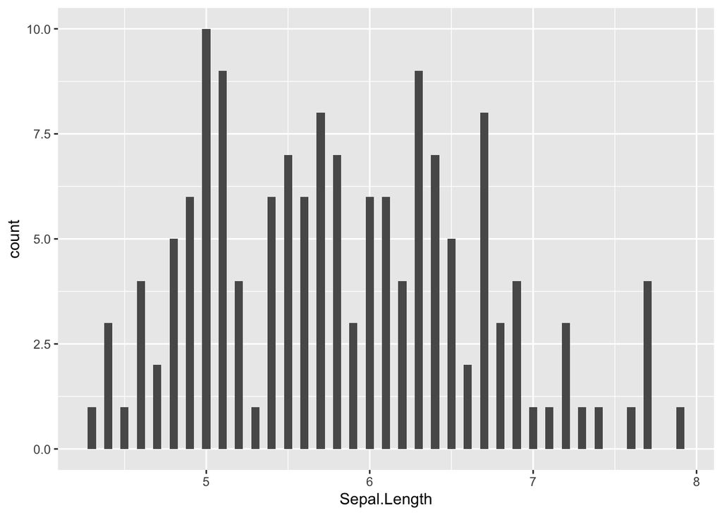

```r
#Histogram for sepal length
ggplot(data = iris, aes(x = Sepal.Length)) +
  geom_histogram(binwidth = 0.05)
```

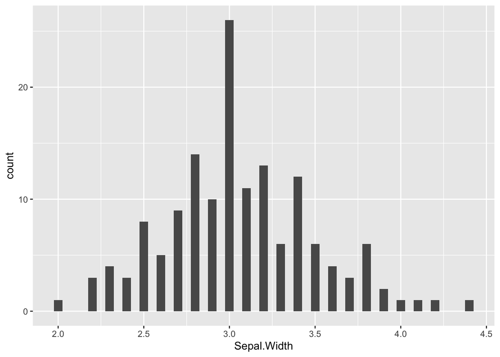

```r
#Histogram for sepal height
ggplot(data = iris, aes(x = Sepal.Width)) +
  geom_histogram(binwidth = 0.05)
```

B). Colour the Sepal Length and Sepal Width histograms based on Species (hint: do we use `colour =`or `fill =`?) What do you notice about the plot? How does height and width vary depending on Species?

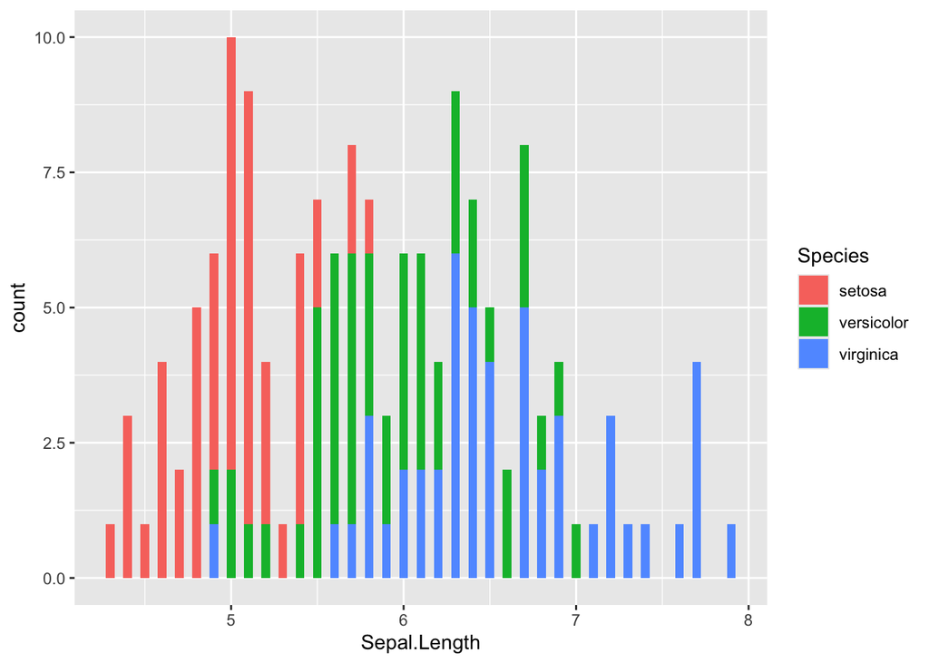

```r
# Histogram for sepal length
ggplot(data = iris, aes(x = Sepal.Length, fill = Species)) +
  geom_histogram(binwidth = 0.05)
```